# Diabetes Readmission Predictive Modelling

Manasvi Saite

2026-03-23

```r
library(tidyverse)
library(dplyr)
select <- dplyr::select
library(caret)
library(randomForest)
library(pROC)
library(ggplot2)
```

## Load Data & Data Cleaning

```r
diabetes <- read.csv("diabetic_data.csv", stringsAsFactors = FALSE)

str(diabetes)
```

```
## 'data.frame':    101766 obs. of  50 variables:
##  $ encounter_id            : int  2278392 149190 64410 500364 16680 35754 55842 63768 12522 15738 ...
##  $ patient_nbr             : int  8222157 55629189 86047875 82442376 42519267 82637451 84259809 114882984 48330783 63555939 ...
##  $ race                    : chr  "Caucasian" "Caucasian" "AfricanAmerican" "Caucasian" ...
##  $ gender                  : chr  "Female" "Female" "Female" "Male" ...
##  $ age                     : chr  "[0-10)" "[10-20)" "[20-30)" "[30-40)" ...
##  $ weight                  : chr  "?" "?" "?" "?" ...
##  $ admission_type_id       : int  6 1 1 1 1 2 3 1 2 3 ...
##  $ discharge_disposition_id: int  25 1 1 1 1 1 1 1 1 3 ...
##  $ admission_source_id     : int  1 7 7 7 7 2 2 7 4 4 ...
##  $ time_in_hospital        : int  1 3 2 2 1 3 4 5 13 12 ...
##  $ payer_code              : chr  "?" "?" "?" "?" ...
##  $ medical_specialty       : chr  "Pediatrics-Endocrinology" "?" "?" "?" ...
##  $ num_lab_procedures      : int  41 59 11 44 51 31 70 73 68 33 ...
##  $ num_procedures          : int  0 0 5 1 0 6 1 0 2 3 ...
```

[output cut: 36 more lines]

```r
dim(diabetes)
```

```
## [1] 101766     50
```

```r
summary(diabetes)
```

```
##   encounter_id        patient_nbr            race              gender
##  Min.   :    12522   Min.   :      135   Length:101766      Length:101766
##  1st Qu.: 84961194   1st Qu.: 23413221   Class :character   Class :character
##  Median :152388987   Median : 45505143   Mode  :character   Mode  :character
##  Mean   :165201646   Mean   : 54330401
##  3rd Qu.:230270888   3rd Qu.: 87545950
##  Max.   :443867222   Max.   :189502619
##      age               weight          admission_type_id
##  Length:101766      Length:101766      Min.   :1.000
##  Class :character   Class :character   1st Qu.:1.000
##  Mode  :character   Mode  :character   Median :1.000
##                                        Mean   :2.024
##                                        3rd Qu.:3.000
##                                        Max.   :8.000
##  discharge_disposition_id admission_source_id time_in_hospital
##  Min.   : 1.000           Min.   : 1.000      Min.   : 1.000
##  1st Qu.: 1.000           1st Qu.: 1.000      1st Qu.: 2.000
##  Median : 1.000           Median : 7.000      Median : 4.000
##  Mean   : 3.716           Mean   : 5.754      Mean   : 4.396
##  3rd Qu.: 4.000           3rd Qu.: 7.000      3rd Qu.: 6.000
##  Max.   :28.000           Max.   :25.000      Max.   :14.000
##   payer_code        medical_specialty  num_lab_procedures num_procedures
##  Length:101766      Length:101766      Min.   :  1.0      Min.   :0.00
##  Class :character   Class :character   1st Qu.: 31.0      1st Qu.:0.00
##  Mode  :character   Mode  :character   Median : 44.0      Median :1.00
##                                        Mean   : 43.1      Mean   :1.34
##                                        3rd Qu.: 57.0      3rd Qu.:2.00
##                                        Max.   :132.0      Max.   :6.00
##  num_medications number_outpatient number_emergency  number_inpatient
##  Min.   : 1.00   Min.   : 0.0000   Min.   : 0.0000   Min.   : 0.0000
##  1st Qu.:10.00   1st Qu.: 0.0000   1st Qu.: 0.0000   1st Qu.: 0.0000
##  Median :15.00   Median : 0.0000   Median : 0.0000   Median : 0.0000
##  Mean   :16.02   Mean   : 0.3694   Mean   : 0.1978   Mean   : 0.6356
##  3rd Qu.:20.00   3rd Qu.: 0.0000   3rd Qu.: 0.0000   3rd Qu.: 1.0000
##  Max.   :81.00   Max.   :42.0000   Max.   :76.0000   Max.   :21.0000
##     diag_1             diag_2             diag_3          number_diagnoses
##  Length:101766      Length:101766      Length:101766      Min.   : 1.000
##  Class :character   Class :character   Class :character   1st Qu.: 6.000
##  Mode  :character   Mode  :character   Mode  :character   Median : 8.000
##                                                           Mean   : 7.423
```

[output cut: 43 more lines]

```
##
##  metformin.rosiglitazone metformin.pioglitazone    change
##  Length:101766           Length:101766          Length:101766
##  Class :character        Class :character       Class :character
##  Mode  :character        Mode  :character       Mode  :character
##
##
##
##  diabetesMed         readmitted
##  Length:101766      Length:101766
##  Class :character   Class :character
##  Mode  :character   Mode  :character
##
##
##
```

```r
table(diabetes$readmitted)
```

```
##
##   <30   >30    NO
## 11357 35545 54864
```

```r
diabetes[diabetes == "?"] <- NA

diabetes$readmit30 <- ifelse(diabetes$readmitted == "<30", 1, 0)
diabetes$readmit30 <- factor(diabetes$readmit30, levels = c(0,1), labels = c("No", "Yes"))

table(diabetes$readmit30)
```

```
##
##    No   Yes
## 90409 11357
```

```r
diabetes <- diabetes %>%
  select(-encounter_id, -patient_nbr, -readmitted)

missing_summary <- sapply(diabetes, function(x) sum(is.na(x)))
missing_table <- data.frame(
  Variable = names(missing_summary),
  Missing_Count = as.numeric(missing_summary),
  Missing_Percent = round(as.numeric(missing_summary) / nrow(diabetes) * 100, 2)
)
missing_table <- missing_table[order(-missing_table$Missing_Count), ]
head(missing_table, 15)
```

```
##                    Variable Missing_Count Missing_Percent
## 4                    weight         98569           96.86
## 10        medical_specialty         49949           49.08
## 9                payer_code         40256           39.56
## 1                      race          2273            2.23
## 19                   diag_3          1423            1.40
## 18                   diag_2           358            0.35
## 17                   diag_1            21            0.02
## 2                    gender             0            0.00
## 3                       age             0            0.00
## 5         admission_type_id             0            0.00
## 6  discharge_disposition_id             0            0.00
## 7       admission_source_id             0            0.00
## 8          time_in_hospital             0            0.00
## 11       num_lab_procedures             0            0.00
## 12           num_procedures             0            0.00
```

## Choose predictors and make a smaller working dataset

```r
model_data <- diabetes %>%
  select(readmit30, race, gender, age, admission_type_id,
         discharge_disposition_id, admission_source_id,
         time_in_hospital, num_lab_procedures, num_procedures,
         num_medications, number_outpatient, number_emergency,
         number_inpatient, number_diagnoses, max_glu_serum,
         A1Cresult, insulin, change, diabetesMed)

str(model_data)
```

```
## 'data.frame':    101766 obs. of  20 variables:
##  $ readmit30               : Factor w/ 2 levels "No","Yes": 1 1 1 1 1 1 1 1 1 1 ...
##  $ race                    : chr  "Caucasian" "Caucasian" "AfricanAmerican" "Caucasian" ...
##  $ gender                  : chr  "Female" "Female" "Female" "Male" ...
##  $ age                     : chr  "[0-10)" "[10-20)" "[20-30)" "[30-40)" ...
##  $ admission_type_id       : int  6 1 1 1 1 2 3 1 2 3 ...
##  $ discharge_disposition_id: int  25 1 1 1 1 1 1 1 1 3 ...
##  $ admission_source_id     : int  1 7 7 7 7 2 2 7 4 4 ...
##  $ time_in_hospital        : int  1 3 2 2 1 3 4 5 13 12 ...
##  $ num_lab_procedures      : int  41 59 11 44 51 31 70 73 68 33 ...
##  $ num_procedures          : int  0 0 5 1 0 6 1 0 2 3 ...
##  $ num_medications         : int  1 18 13 16 8 16 21 12 28 18 ...
##  $ number_outpatient       : int  0 0 2 0 0 0 0 0 0 0 ...
##  $ number_emergency        : int  0 0 0 0 0 0 0 0 0 0 ...
##  $ number_inpatient        : int  0 0 1 0 0 0 0 0 0 0 ...
##  $ number_diagnoses        : int  1 9 6 7 5 9 7 8 8 8 ...
##  $ max_glu_serum           : chr  "None" "None" "None" "None" ...
##  $ A1Cresult               : chr  "None" "None" "None" "None" ...
##  $ insulin                 : chr  "No" "Up" "No" "Up" ...
##  $ change                  : chr  "No" "Ch" "No" "Ch" ...
##  $ diabetesMed             : chr  "No" "Yes" "Yes" "Yes" ...
```

```r
summary(model_data)
```

```
##  readmit30       race              gender              age
##  No :90409   Length:101766      Length:101766      Length:101766
##  Yes:11357   Class :character   Class :character   Class :character
##              Mode  :character   Mode  :character   Mode  :character
##
##
##
##  admission_type_id discharge_disposition_id admission_source_id
##  Min.   :1.000     Min.   : 1.000           Min.   : 1.000
##  1st Qu.:1.000     1st Qu.: 1.000           1st Qu.: 1.000
##  Median :1.000     Median : 1.000           Median : 7.000
##  Mean   :2.024     Mean   : 3.716           Mean   : 5.754
##  3rd Qu.:3.000     3rd Qu.: 4.000           3rd Qu.: 7.000
##  Max.   :8.000     Max.   :28.000           Max.   :25.000
##  time_in_hospital num_lab_procedures num_procedures num_medications
##  Min.   : 1.000   Min.   :  1.0      Min.   :0.00   Min.   : 1.00
##  1st Qu.: 2.000   1st Qu.: 31.0      1st Qu.:0.00   1st Qu.:10.00
##  Median : 4.000   Median : 44.0      Median :1.00   Median :15.00
##  Mean   : 4.396   Mean   : 43.1      Mean   :1.34   Mean   :16.02
##  3rd Qu.: 6.000   3rd Qu.: 57.0      3rd Qu.:2.00   3rd Qu.:20.00
##  Max.   :14.000   Max.   :132.0      Max.   :6.00   Max.   :81.00
##  number_outpatient number_emergency  number_inpatient  number_diagnoses
##  Min.   : 0.0000   Min.   : 0.0000   Min.   : 0.0000   Min.   : 1.000
##  1st Qu.: 0.0000   1st Qu.: 0.0000   1st Qu.: 0.0000   1st Qu.: 6.000
##  Median : 0.0000   Median : 0.0000   Median : 0.0000   Median : 8.000
##  Mean   : 0.3694   Mean   : 0.1978   Mean   : 0.6356   Mean   : 7.423
##  3rd Qu.: 0.0000   3rd Qu.: 0.0000   3rd Qu.: 1.0000   3rd Qu.: 9.000
##  Max.   :42.0000   Max.   :76.0000   Max.   :21.0000   Max.   :16.000
##  max_glu_serum       A1Cresult           insulin             change
##  Length:101766      Length:101766      Length:101766      Length:101766
##  Class :character   Class :character   Class :character   Class :character
##  Mode  :character   Mode  :character   Mode  :character   Mode  :character
##
##
##
##  diabetesMed
##  Length:101766
##  Class :character
##  Mode  :character
##
##
##
```

## Convert categorical variables

```r
model_data$readmit30 <- factor(model_data$readmit30, levels = c("No", "Yes"))
model_data$race <- factor(model_data$race)
model_data$gender <- factor(model_data$gender)
model_data$age <- factor(model_data$age, ordered = TRUE)
model_data$admission_type_id <- factor(model_data$admission_type_id)
model_data$discharge_disposition_id <- factor(model_data$discharge_disposition_id)
model_data$admission_source_id <- factor(model_data$admission_source_id)
model_data$max_glu_serum <- factor(model_data$max_glu_serum)
model_data$A1Cresult <- factor(model_data$A1Cresult)
model_data$insulin <- factor(model_data$insulin)
model_data$change <- factor(model_data$change)
model_data$diabetesMed <- factor(model_data$diabetesMed)

str(model_data)
```

```
## 'data.frame':    101766 obs. of  20 variables:
##  $ readmit30               : Factor w/ 2 levels "No","Yes": 1 1 1 1 1 1 1 1 1 1 ...
##  $ race                    : Factor w/ 5 levels "AfricanAmerican",..: 3 3 1 3 3 3 3 3 3 3 ...
##  $ gender                  : Factor w/ 3 levels "Female","Male",..: 1 1 1 2 2 2 2 2 1 1 ...
##  $ age                     : Ord.factor w/ 10 levels "[0-10)"<"[10-20)"<..: 1 2 3 4 5 6 7 8 9 10 ...
##  $ admission_type_id       : Factor w/ 8 levels "1","2","3","4",..: 6 1 1 1 1 2 3 1 2 3 ...
##  $ discharge_disposition_id: Factor w/ 26 levels "1","2","3","4",..: 24 1 1 1 1 1 1 1 1 3 ...
##  $ admission_source_id     : Factor w/ 17 levels "1","2","3","4",..: 1 7 7 7 7 2 2 7 4 4 ...
##  $ time_in_hospital        : int  1 3 2 2 1 3 4 5 13 12 ...
##  $ num_lab_procedures      : int  41 59 11 44 51 31 70 73 68 33 ...
##  $ num_procedures          : int  0 0 5 1 0 6 1 0 2 3 ...
##  $ num_medications         : int  1 18 13 16 8 16 21 12 28 18 ...
##  $ number_outpatient       : int  0 0 2 0 0 0 0 0 0 0 ...
##  $ number_emergency        : int  0 0 0 0 0 0 0 0 0 0 ...
##  $ number_inpatient        : int  0 0 1 0 0 0 0 0 0 0 ...
##  $ number_diagnoses        : int  1 9 6 7 5 9 7 8 8 8 ...
##  $ max_glu_serum           : Factor w/ 4 levels ">200",">300",..: 3 3 3 3 3 3 3 3 3 3 ...
##  $ A1Cresult               : Factor w/ 4 levels ">7",">8","None",..: 3 3 3 3 3 3 3 3 3 3 ...
##  $ insulin                 : Factor w/ 4 levels "Down","No","Steady",..: 2 4 2 4 3 3 3 2 3 3 ...
##  $ change                  : Factor w/ 2 levels "Ch","No": 2 1 2 1 1 2 1 2 1 1 ...
##  $ diabetesMed             : Factor w/ 2 levels "No","Yes": 1 2 2 2 2 2 2 2 2 2 ...
```

## Remove missing values for first simple model

```r
model_data_clean <- na.omit(model_data)
dim(model_data_clean)
```

```
## [1] 99493    20
```

```r
prop.table(table(model_data_clean$readmit30))
```

```
##
##        No       Yes
## 0.8877408 0.1122592
```

## Take a random sample to make modelling more manageable

```r
set.seed(123)

sample_n_rows <- min(20000, nrow(model_data_clean))
model_data_sample <- model_data_clean[sample(seq_len(nrow(model_data_clean)), sample_n_rows), ]

dim(model_data_sample)
```

```
## [1] 20000    20
```

```r
prop.table(table(model_data_sample$readmit30))
```

```
##
##     No    Yes
## 0.8902 0.1098
```

## Train-test split

```r
set.seed(123)

train_index <- createDataPartition(model_data_sample$readmit30, p = 0.7, list = FALSE)
train_data <- model_data_sample[train_index, ]
test_data  <- model_data_sample[-train_index, ]

dim(train_data)
```

```
## [1] 14001    20
```

```r
dim(test_data)
```

```
## [1] 5999   20
```

## Fix factor levels and variable types in test data

```r
factor_vars <- names(train_data)[sapply(train_data, is.factor)]

keep_rows <- rep(TRUE, nrow(test_data))

for (v in factor_vars) {
  train_levels <- unique(as.character(train_data[[v]]))
  test_values  <- as.character(test_data[[v]])
  keep_rows <- keep_rows & (is.na(test_values) | test_values %in% train_levels)
}

test_data <- test_data[keep_rows, ]

for (v in names(train_data)) {
  if (is.factor(train_data[[v]])) {
    test_data[[v]] <- factor(
      test_data[[v]],
      levels = levels(train_data[[v]]),
      ordered = is.ordered(train_data[[v]])
    )
  } else if (is.integer(train_data[[v]])) {
    test_data[[v]] <- as.integer(test_data[[v]])
  } else if (is.numeric(train_data[[v]])) {
    test_data[[v]] <- as.numeric(test_data[[v]])
  } else if (is.character(train_data[[v]])) {
    test_data[[v]] <- as.character(test_data[[v]])
  }
}

train_data <- droplevels(train_data)
test_data  <- droplevels(test_data)

str(train_data)
```

```
## 'data.frame':    14001 obs. of  20 variables:
##  $ readmit30               : Factor w/ 2 levels "No","Yes": 1 1 1 1 1 1 1 1 2 1 ...
##  $ race                    : Factor w/ 5 levels "AfricanAmerican",..: 3 3 3 1 3 3 3 1 1 4 ...
##  $ gender                  : Factor w/ 2 levels "Female","Male": 2 1 1 2 2 1 1 2 1 1 ...
##  $ age                     : Ord.factor w/ 10 levels "[0-10)"<"[10-20)"<..: 7 7 9 6 8 9 7 5 7 8 ...
##  $ admission_type_id       : Factor w/ 8 levels "1","2","3","4",..: 1 6 3 1 1 2 3 1 1 2 ...
##  $ discharge_disposition_id: Factor w/ 23 levels "1","2","3","4",..: 1 1 3 1 1 19 1 1 1 1 ...
##  $ admission_source_id     : Factor w/ 13 levels "1","2","3","4",..: 1 7 1 7 7 7 1 7 7 7 ...
##  $ time_in_hospital        : int  3 1 3 2 3 6 4 2 8 7 ...
##  $ num_lab_procedures      : int  62 43 38 39 52 47 56 59 21 67 ...
##  $ num_procedures          : int  0 0 1 0 2 0 1 0 3 4 ...
##  $ num_medications         : int  21 8 33 11 13 20 26 9 12 26 ...
##  $ number_outpatient       : int  3 0 1 0 1 0 0 0 0 0 ...
##  $ number_emergency        : int  0 0 0 2 0 0 0 0 0 0 ...
##  $ number_inpatient        : int  0 0 0 1 0 0 1 0 1 0 ...
##  $ number_diagnoses        : int  9 3 3 9 9 9 6 3 7 9 ...
##  $ max_glu_serum           : Factor w/ 4 levels ">200",">300",..: 3 1 3 3 3 3 3 3 3 3 ...
##  $ A1Cresult               : Factor w/ 4 levels ">7",">8","None",..: 3 3 3 3 3 3 3 2 3 3 ...
##  $ insulin                 : Factor w/ 4 levels "Down","No","Steady",..: 3 2 2 4 2 4 1 3 2 1 ...
##  $ change                  : Factor w/ 2 levels "Ch","No": 1 2 2 1 1 1 1 1 2 1 ...
##  $ diabetesMed             : Factor w/ 2 levels "No","Yes": 2 2 2 2 2 2 2 2 1 2 ...
##  - attr(*, "na.action")= 'omit' Named int [1:2273] 20 21 22 55 66 88 100 112 128 178 ...
##   ..- attr(*, "names")= chr [1:2273] "20" "21" "22" "55" ...
```

```r
str(test_data)
```

```
## 'data.frame':    5999 obs. of  20 variables:
##  $ readmit30               : Factor w/ 2 levels "No","Yes": 2 1 1 1 2 1 1 1 1 2 ...
##  $ race                    : Factor w/ 5 levels "AfricanAmerican",..: 3 3 3 3 3 3 3 3 4 3 ...
##  $ gender                  : Factor w/ 2 levels "Female","Male": 1 2 1 1 2 1 1 2 1 2 ...
##  $ age                     : Ord.factor w/ 10 levels "[0-10)"<"[10-20)"<..: 5 5 9 9 7 7 9 8 7 8 ...
##  $ admission_type_id       : Factor w/ 7 levels "1","2","3","5",..: 1 2 3 1 1 1 4 1 2 1 ...
##  $ discharge_disposition_id: Factor w/ 20 levels "1","2","3","4",..: 1 1 4 3 3 3 6 6 1 1 ...
##  $ admission_source_id     : Factor w/ 11 levels "1","2","3","4",..: 7 7 1 7 7 7 1 7 7 7 ...
##  $ time_in_hospital        : int  3 3 5 2 6 3 2 7 5 3 ...
##  $ num_lab_procedures      : int  50 49 31 53 35 67 1 57 50 57 ...
##  $ num_procedures          : int  0 2 0 1 3 0 1 2 2 0 ...
##  $ num_medications         : int  15 22 14 20 13 10 12 21 18 17 ...
##  $ number_outpatient       : int  0 0 0 1 0 0 1 2 0 0 ...
##  $ number_emergency        : int  0 0 0 2 0 0 0 0 1 0 ...
##  $ number_inpatient        : int  2 0 1 2 0 0 1 0 1 3 ...
##  $ number_diagnoses        : int  7 8 8 9 9 9 3 9 9 8 ...
##  $ max_glu_serum           : Factor w/ 4 levels ">200",">300",..: 3 3 3 3 3 3 3 3 3 3 ...
##  $ A1Cresult               : Factor w/ 4 levels ">7",">8","None",..: 3 2 3 3 3 3 3 1 1 3 ...
##  $ insulin                 : Factor w/ 4 levels "Down","No","Steady",..: 2 1 2 3 2 1 4 4 1 2 ...
##  $ change                  : Factor w/ 2 levels "Ch","No": 2 1 1 1 2 1 1 1 1 2 ...
##  $ diabetesMed             : Factor w/ 2 levels "No","Yes": 1 2 2 2 2 2 2 2 2 2 ...
##  - attr(*, "na.action")= 'omit' Named int [1:2273] 20 21 22 55 66 88 100 112 128 178 ...
##   ..- attr(*, "names")= chr [1:2273] "20" "21" "22" "55" ...
```

## Exploratory Data Analysis

## Boxplot: Time in Hospital vs Readmission

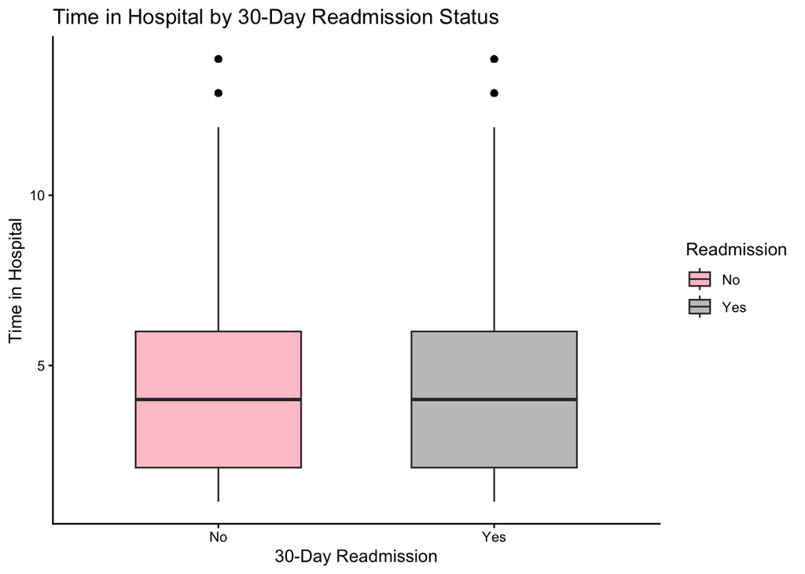

```r
ggplot(model_data, aes(x = readmit30, y = time_in_hospital, fill = readmit30)) +
  geom_boxplot(width = 0.6, alpha = 0.9, outlier.color = "black") +
  scale_fill_manual(values = c("No" = "pink", "Yes" = "grey")) +
  labs(
    title = "Time in Hospital by 30-Day Readmission Status",
    x = "30-Day Readmission",
    y = "Time in Hospital",
    fill = "Readmission"
  ) +
  theme_classic()
```

## A bar chart of readmission counts

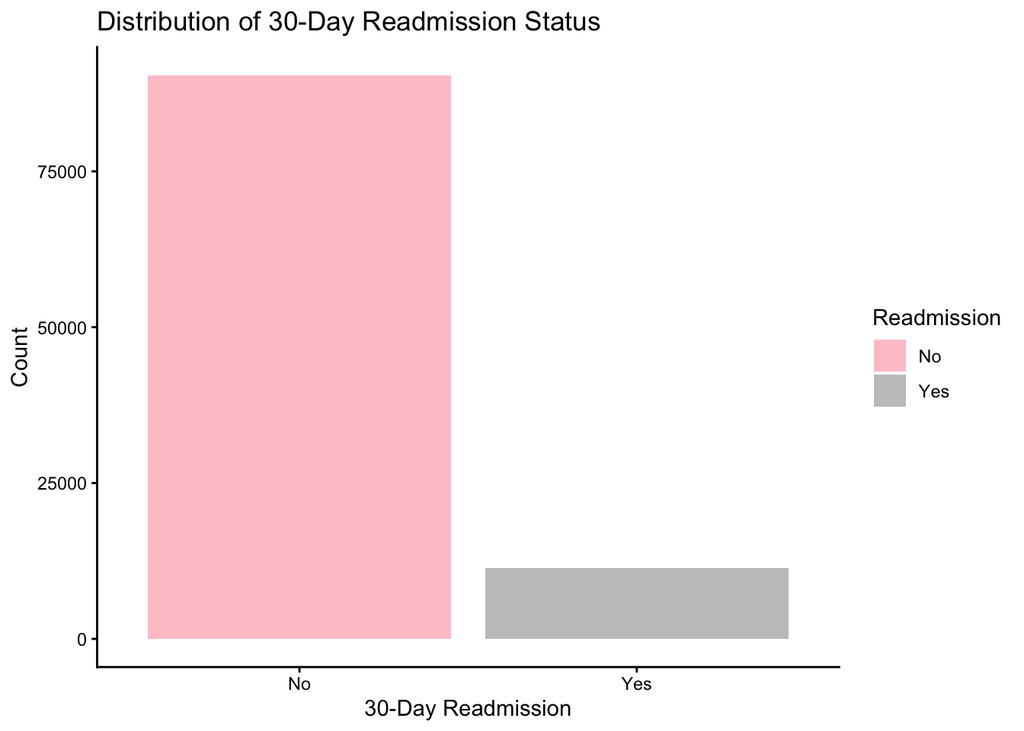

```r
ggplot(model_data, aes(x = readmit30, fill = readmit30)) +
  geom_bar(alpha = 0.9) +
  scale_fill_manual(values = c("No" = "pink", "Yes" = "grey")) +
  labs(
    title = "Distribution of 30-Day Readmission Status",
    x = "30-Day Readmission",
    y = "Count",
    fill = "Readmission"
  ) +
  theme_classic()
```

## Logistic regression

```r
log_model <- glm(readmit30 ~ ., data = train_data, family = binomial)

summary(log_model)
```

```
##
## Call:
## glm(formula = readmit30 ~ ., family = binomial, data = train_data)
##
## Coefficients:
##                              Estimate Std. Error z value Pr(>|z|)
## (Intercept)                -2.982e+00  3.920e-01  -7.606 2.84e-14 ***
## raceAsian                   8.171e-01  2.848e-01   2.869 0.004114 **
## raceCaucasian              -2.008e-03  7.437e-02  -0.027 0.978458
## raceHispanic               -2.373e-02  2.116e-01  -0.112 0.910722
## raceOther                  -4.070e-02  2.556e-01  -0.159 0.873481
## genderMale                  6.312e-02  5.679e-02   1.112 0.266317
## age.L                       9.694e-01  5.641e-01   1.718 0.085710 .
## age.Q                      -5.338e-01  5.543e-01  -0.963 0.335521
## age.C                       3.605e-01  4.865e-01   0.741 0.458624
## age^4                       7.118e-02  4.175e-01   0.170 0.864630
## age^5                      -3.352e-01  3.508e-01  -0.955 0.339427
## age^6                       2.886e-01  2.738e-01   1.054 0.291820
## age^7                      -1.193e-01  1.972e-01  -0.605 0.545251
## age^8                      -1.995e-03  1.394e-01  -0.014 0.988587
## age^9                      -5.254e-02  9.861e-02  -0.533 0.594185
## admission_type_id2         -1.880e-01  9.708e-02  -1.937 0.052767 .
## admission_type_id3         -2.606e-01  1.196e-01  -2.179 0.029321 *
## admission_type_id4         -1.503e+01  2.400e+03  -0.006 0.995001
## admission_type_id5         -1.825e-01  1.905e-01  -0.958 0.337993
## admission_type_id6         -1.206e-02  1.720e-01  -0.070 0.944094
## admission_type_id7         -1.418e+01  1.385e+03  -0.010 0.991831
## admission_type_id8         -4.777e-01  6.086e-01  -0.785 0.432564
## discharge_disposition_id2   6.365e-01  1.643e-01   3.873 0.000107 ***
## discharge_disposition_id3   4.443e-01  8.729e-02   5.090 3.59e-07 ***
## discharge_disposition_id4   1.900e-01  3.102e-01   0.612 0.540213
## discharge_disposition_id5   1.280e+00  1.948e-01   6.570 5.02e-11 ***
## discharge_disposition_id6   3.597e-01  8.639e-02   4.164 3.13e-05 ***
## discharge_disposition_id7   8.027e-01  2.999e-01   2.677 0.007433 **
## discharge_disposition_id8  -1.617e-01  1.054e+00  -0.153 0.878017
## discharge_disposition_id9   1.025e+00  1.287e+00   0.797 0.425653
## discharge_disposition_id10 -1.475e+01  2.400e+03  -0.006 0.995095
## discharge_disposition_id11 -1.459e+01  1.501e+02  -0.097 0.922604
## discharge_disposition_id13 -9.934e-01  6.001e-01  -1.655 0.097832 .
## discharge_disposition_id14 -3.974e-01  5.303e-01  -0.750 0.453540
```

[output cut: 36 more lines]

```
## insulinNo                  -4.106e-01  1.122e-01  -3.660 0.000253 ***
## insulinSteady              -3.674e-01  1.016e-01  -3.617 0.000298 ***
## insulinUp                  -1.567e-01  1.089e-01  -1.438 0.150308
## changeNo                    2.573e-01  8.130e-02   3.165 0.001552 **
## diabetesMedYes              1.501e-01  8.897e-02   1.687 0.091605 .
## ---
## Signif. codes:  0 '***' 0.001 '**' 0.01 '*' 0.05 '.' 0.1 ' ' 1
##
## (Dispersion parameter for binomial family taken to be 1)
##
##     Null deviance: 9694.3  on 14000  degrees of freedom
## Residual deviance: 9064.6  on 13926  degrees of freedom
## AIC: 9214.6
##
## Number of Fisher Scoring iterations: 15
```

## Odds ratios from logistic regression

```r
log_or <- data.frame(
  Variable = names(coef(log_model)),
  Odds_Ratio = exp(coef(log_model)),
  row.names = NULL
)
head(log_or, 15)
```

```
##         Variable Odds_Ratio
## 1    (Intercept) 0.05071647
## 2      raceAsian 2.26399168
## 3  raceCaucasian 0.99799397
## 4   raceHispanic 0.97654769
## 5      raceOther 0.96011634
## 6     genderMale 1.06515725
## 7          age.L 2.63626230
## 8          age.Q 0.58634512
## 9          age.C 1.43411585
## 10         age^4 1.07377411
## 11         age^5 0.71522953
## 12         age^6 1.33452774
## 13         age^7 0.88754873
## 14         age^8 0.99800750
## 15         age^9 0.94881796
```

## Logistic regression prediction

```r
log_probs <- predict(log_model, newdata = test_data, type = "response")
log_pred <- ifelse(log_probs > 0.5, "Yes", "No")
log_pred <- factor(log_pred, levels = c("No", "Yes"))

log_cm <- confusionMatrix(log_pred, test_data$readmit30, positive = "Yes")
log_cm
```

```
## Confusion Matrix and Statistics
##
##           Reference
## Prediction   No  Yes
##        No  5326  645
##        Yes   15   13
##
##                Accuracy : 0.89
##                  95% CI : (0.8818, 0.8978)
##     No Information Rate : 0.8903
##     P-Value [Acc > NIR] : 0.5432
##
##                   Kappa : 0.0292
##
##  Mcnemar's Test P-Value : <2e-16
##
##             Sensitivity : 0.019757
##             Specificity : 0.997192
##          Pos Pred Value : 0.464286
##          Neg Pred Value : 0.891978
##              Prevalence : 0.109685
##          Detection Rate : 0.002167
##    Detection Prevalence : 0.004667
##       Balanced Accuracy : 0.508474
##
##        'Positive' Class : Yes
##
```

## Logistic regression ROC-AUC

```r
log_roc <- roc(test_data$readmit30, log_probs,
               levels = c("No", "Yes"), direction = "<")

log_auc <- auc(log_roc)
log_auc
```

```
## Area under the curve: 0.6737
```

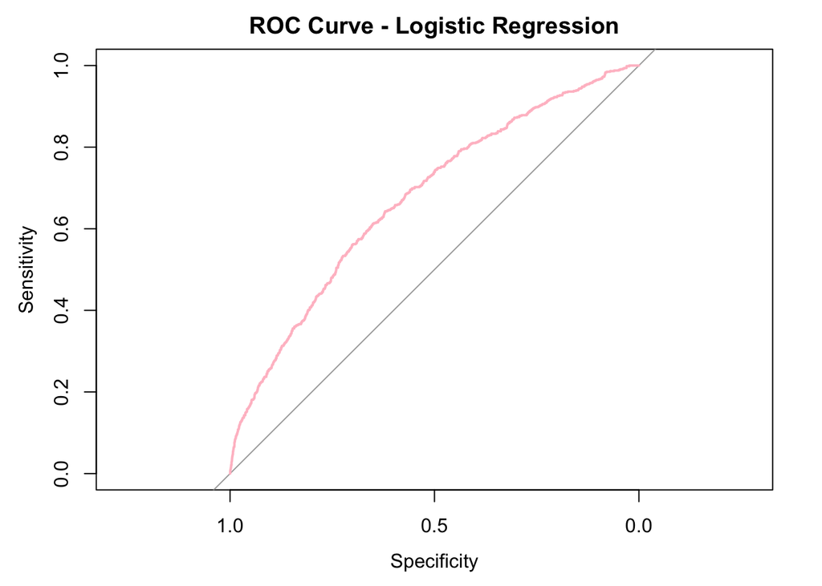

```r
plot(log_roc, col = "pink", lwd = 2,
     main = "ROC Curve - Logistic Regression")
```

## Random forest

```r
set.seed(123)

rf_model <- randomForest(readmit30 ~ ., data = train_data, ntree = 100, importance = TRUE)

print(rf_model)
```

```
##
## Call:
##  randomForest(formula = readmit30 ~ ., data = train_data, ntree = 100,      importance = TRUE)
##                Type of random forest: classification
##                      Number of trees: 100
## No. of variables tried at each split: 4
##
##         OOB estimate of  error rate: 11.11%
## Confusion matrix:
##        No Yes class.error
## No  12421  42 0.003369975
## Yes  1514  24 0.984395319
```

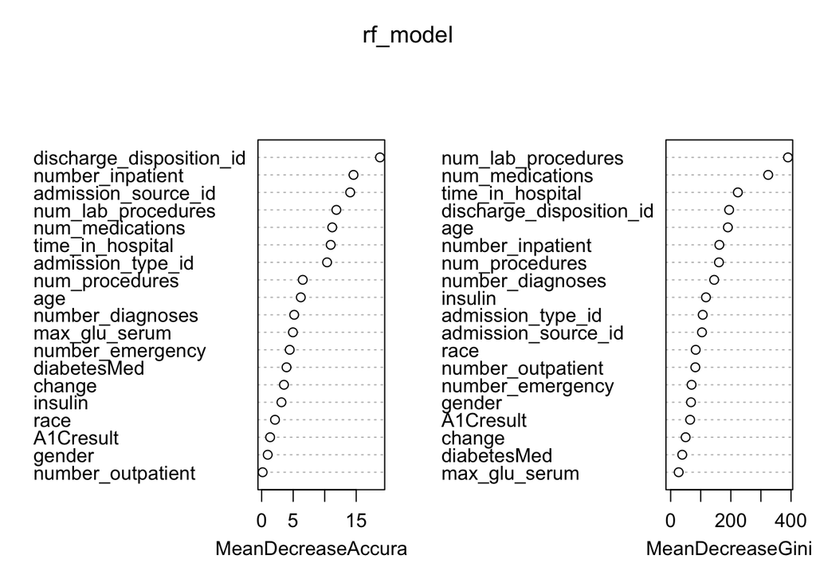

```r
varImpPlot(rf_model)
```

## Random forest prediction

```r
for (v in names(train_data)) {
  if (is.factor(train_data[[v]])) {
    test_data[[v]] <- factor(
      test_data[[v]],
      levels = levels(train_data[[v]]),
      ordered = is.ordered(train_data[[v]])
    )
  } else if (is.integer(train_data[[v]])) {
    test_data[[v]] <- as.integer(test_data[[v]])
  } else if (is.numeric(train_data[[v]])) {
    test_data[[v]] <- as.numeric(test_data[[v]])
  }
}

rf_pred_prob <- predict(rf_model, newdata = test_data, type = "prob")[, "Yes"]
rf_pred <- predict(rf_model, newdata = test_data, type = "response")

rf_cm <- confusionMatrix(rf_pred, test_data$readmit30, positive = "Yes")
rf_cm
```

```
## Confusion Matrix and Statistics
##
##           Reference
## Prediction   No  Yes
##        No  5328  648
##        Yes   13   10
##
##                Accuracy : 0.8898
##                  95% CI : (0.8816, 0.8976)
##     No Information Rate : 0.8903
##     P-Value [Acc > NIR] : 0.5596
##
##                   Kappa : 0.0221
##
##  Mcnemar's Test P-Value : <2e-16
##
##             Sensitivity : 0.015198
##             Specificity : 0.997566
##          Pos Pred Value : 0.434783
##          Neg Pred Value : 0.891566
##              Prevalence : 0.109685
##          Detection Rate : 0.001667
##    Detection Prevalence : 0.003834
##       Balanced Accuracy : 0.506382
##
##        'Positive' Class : Yes
##
```

## Random forest ROC-AUC

```r
rf_roc <- roc(test_data$readmit30, rf_pred_prob,
              levels = c("No", "Yes"), direction = "<")

rf_auc <- auc(rf_roc)
rf_auc
```

```
## Area under the curve: 0.6339
```

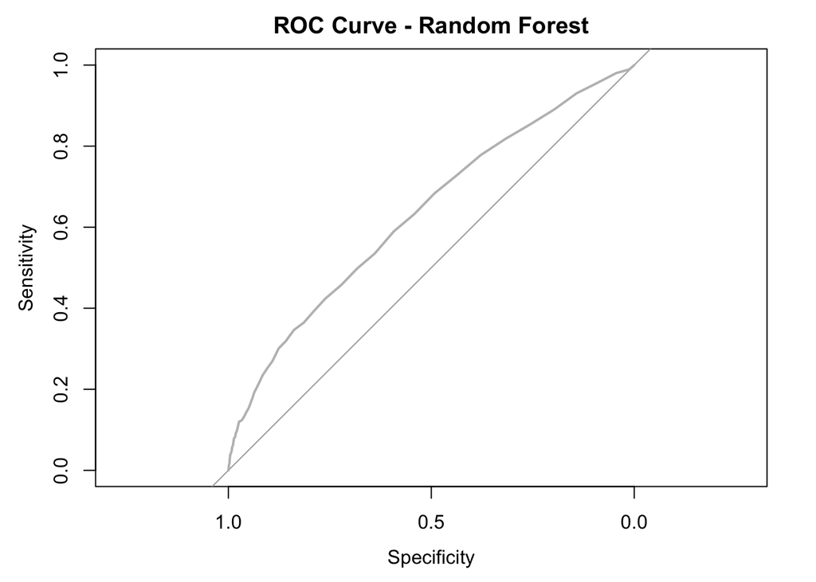

```r
plot(rf_roc, col = "grey", lwd = 2,
     main = "ROC Curve - Random Forest")
```

## Important variables from random forest

```r
rf_importance <- importance(rf_model)
rf_importance_table <- data.frame(
  Variable = rownames(rf_importance),
  MeanDecreaseGini = rf_importance[, "MeanDecreaseGini"],
  row.names = NULL
)
rf_importance_table <- rf_importance_table[order(-rf_importance_table$MeanDecreaseGini), ]
head(rf_importance_table, 15)
```

```
##                    Variable MeanDecreaseGini
## 8        num_lab_procedures        389.98195
## 10          num_medications        324.25180
## 7          time_in_hospital        223.38042
## 5  discharge_disposition_id        194.40184
## 3                       age        190.20125
## 13         number_inpatient        161.87538
## 9            num_procedures        160.61010
## 14         number_diagnoses        144.70185
## 17                  insulin        117.38706
## 4         admission_type_id        106.64747
## 6       admission_source_id        104.17467
## 1                      race         83.28132
## 11        number_outpatient         82.08920
## 12         number_emergency         69.61512
## 2                    gender         67.66423
```

## Model evaluation table

```r
results_table <- data.frame(
  Model = c("Logistic Regression", "Random Forest"),
  Accuracy = c(log_cm$overall["Accuracy"], rf_cm$overall["Accuracy"]),
  Sensitivity = c(log_cm$byClass["Sensitivity"], rf_cm$byClass["Sensitivity"]),
  Specificity = c(log_cm$byClass["Specificity"], rf_cm$byClass["Specificity"]),
  AUC = c(as.numeric(log_auc), as.numeric(rf_auc))
)
results_table
```

```
##                 Model  Accuracy Sensitivity Specificity       AUC
## 1 Logistic Regression 0.8899817  0.01975684   0.9971915 0.6736936
## 2       Random Forest 0.8898150  0.01519757   0.9975660 0.6339278
```

## ROC comparison plot

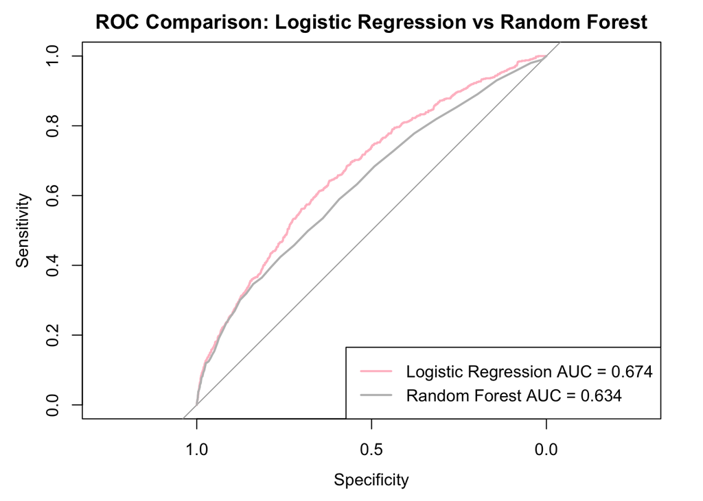

```r
plot(log_roc, col = "pink", lwd = 2,
     main = "ROC Comparison: Logistic Regression vs Random Forest")

plot(rf_roc, col = "grey", lwd = 2, add = TRUE)

legend("bottomright",
       legend = c(paste("Logistic Regression AUC =", round(log_auc, 3)),
                  paste("Random Forest AUC =", round(rf_auc, 3))),
       col = c("pink", "grey"),
       lwd = 2)
```

## Discussion:

Overall, while logistic regression was slightly better and more interpretable, both models are limited in practical use due to poor detection of readmitted patients. Improvements such as handling class imbalance or applying more advanced modelling techniques could enhance performance.

## Limitation:

The dataset is highly imbalanced, with far more non-readmitted patients than readmitted ones. This leads to high accuracy but very low sensitivity. Both models showed very poor ability to detect readmitted patients, which limits their usefulness in real clinical settings. Missing data were handled using complete-case analysis, which may result in loss of information and potential bias. The models used are relatively simple (logistic regression and random forest without extensive tuning), so more advanced methods may improve performance. The dataset is observational, so it may contain noise or unmeasured factors that affect prediction accuracy.

## Conclusion:

Logistic regression performed slightly better than random forest in terms of AUC, while both models showed similar accuracy. However, both models had very low sensitivity, indicating poor ability to detect readmitted patients.